# Visualizing 201902-Fordgobike-Tripdata

## By: Adham Hussein

## Investigation Overview

> In this investigation, I wanted to look at to the User type behaviour , I focused on age, gender, duration, and user type to analyze and understand the usage of bike with diffrent questations?

## Dataset Overview

> The forgobike trip data are 183,412 rides that happend in Febraury month of 2019 . The dataset is contain 16 columns before I did cleaning. Some attributes duration_sec, start_time, end_time, start_station_id, start_station_name, and member_age. I downloaded the data set from course resources of project details. I delete all user more than 75 years old because most users are between 18-75 year old . Also I created new columns like duration_min, start_hourofday,start_dayOfweek and member age. After I cleaned my data and craeted new columns the data became 174884 records and 21 columns

## Visualization 1

> From the below visualization we find The distribution of day_week Usage of Bike Rides

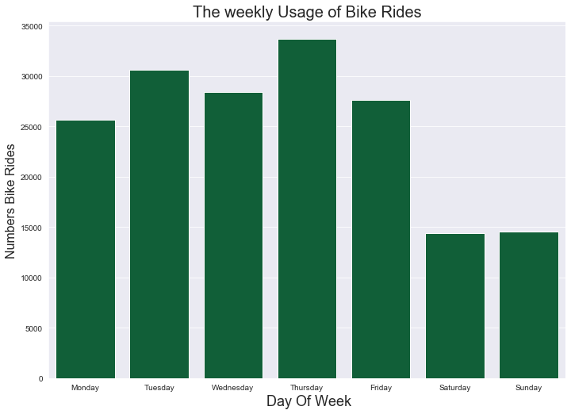

> As we see Thursady is the most week of day used to ride bike and saturday,sunday are lesst becouse of weekend.

## Visualization 2

> From the below visualization we find The distribution of hours of day Usage of Bike Rides

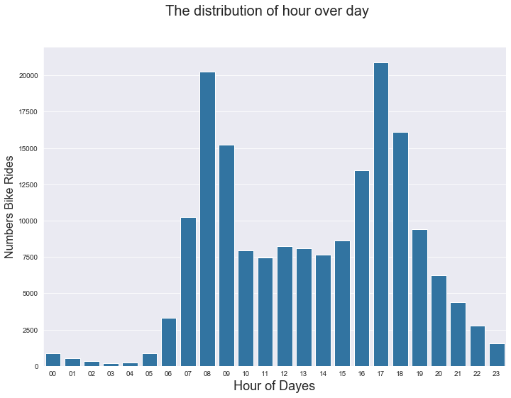

#### As we see that 8:AM and 5:PM most used hours of days and i think that becouse of most of people use bikes to go and come from work

## Visualization 3

> we need to find out The distribution of member_gender propation of Bike Rides

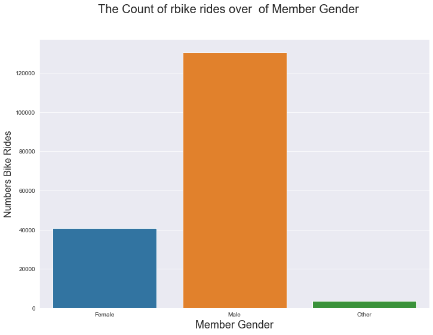

##### AS we see from the previous figure males are most used bikes

## Visualization 4

> we need to find out The relation between two categorical variables distrbutions member_gender propation over week of day.

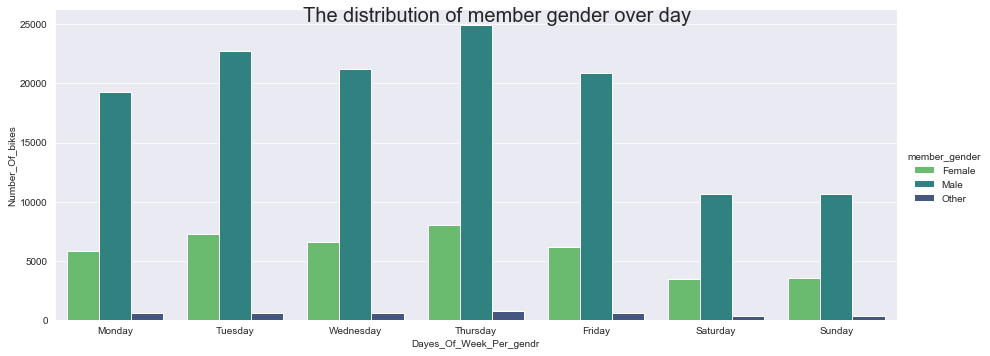

#### from the above figure we conclude that males are most use bikes all over dayes of week .

## Visualization 5

> The relation between User_type usage of bikes over dayes

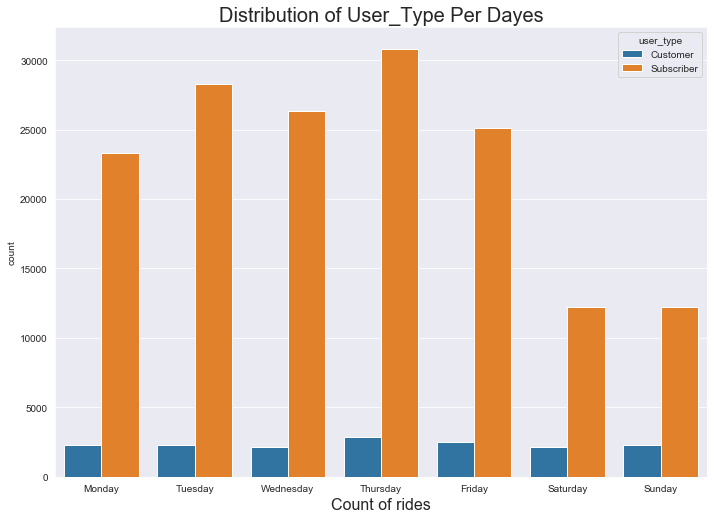

#### we conclude that Subscriber are the most use bikes all over dayes of week .

## Visualization 6

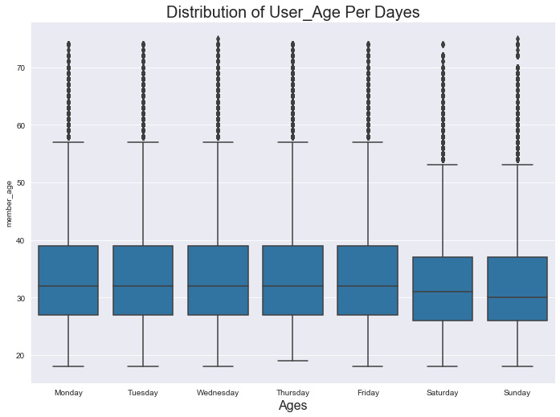

#### As we see weekend is less than rides of work dayes and most of ages is between 27 and 39 years old

## Visualization 7

> the distributions of users type over duration_minate

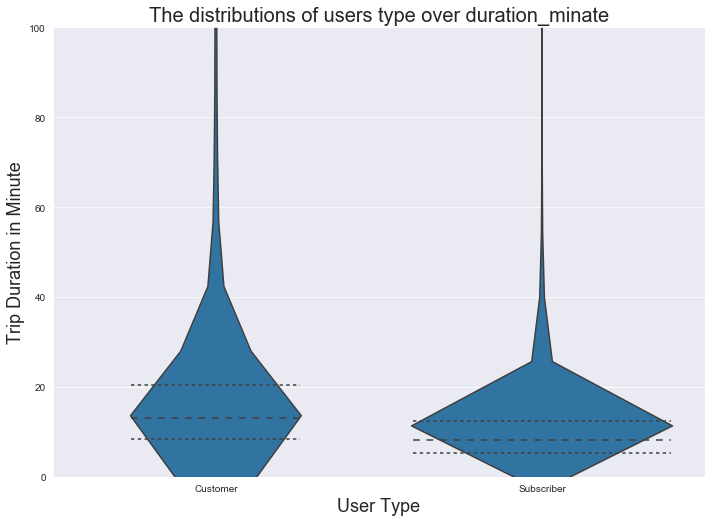

#### The trip duration distribution is tight for subscribers, but wide for customer . It seems like subscribers have a more specific usage or targeted place riding the bikes on the othe hand customers rented the bikes for longer.

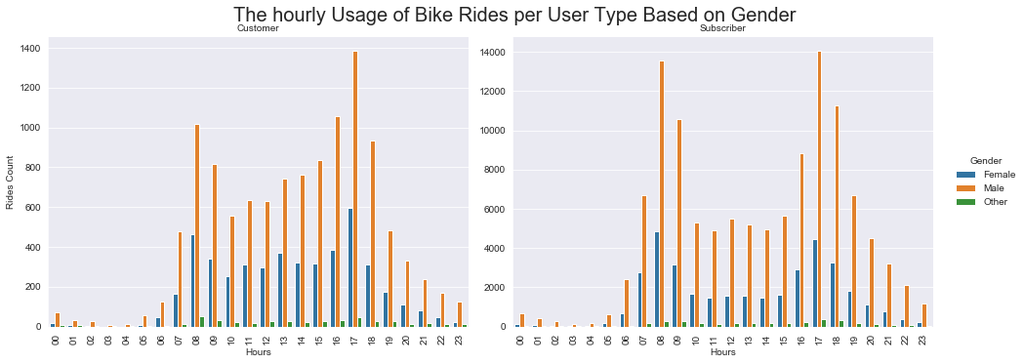